# Introduction to Medical Statistics 2024 Exercises Class IV Normal distribution and the Confidence Intervals

Authors

Thuan Hoang

Ronald Geskus

Published

March 24, 2026

## I. Calculation of normal probabilities

Below is a bell-shaped curve demonstrating a Standard Normal distribution. In R, function `pnorm(x, mean, sd)` is a function to quantify the probability $P(X \leq x)$ from a Normal distribution with mean `mean` and standard deviation `sd`.

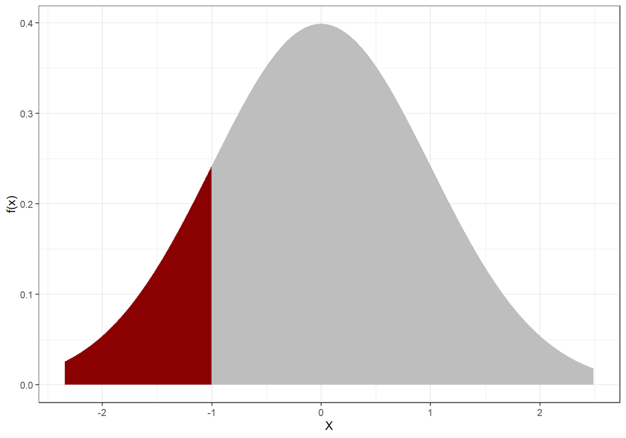

Figure 1: Given X ~ Normal(0,1). The curve represents the probability density function of x. The probability of x < -1 (P(x < -1) is highlighted in red. Do you see that it is symmetrical?

Assume that the probability distribution of a laboratory marker in a population has a normal distribution with mean 75 and standard deviation 15. Use the 68-95-99.7-rule to (approximately) calculate the following probabilities by hand. Use the `pnorm` function in R to confirm your approximations.

1. P(60<X<90)

```r
pnorm(60, mean=75, sd=15) - pnorm(75, mean=75, sd=15)
```

2. P(X<60)

```r
1-pnorm(60, mean=75, sd=15)
```

3. P(X>90)

```r
1-pnorm(60, mean=75, sd=15)
```

```r
# or pnorm(90, mean=75, sd=15, lower.tail=FALSE)
```

4. P(X<60 or X>105)

*Answer: (105-75)/15=2 About 95% is within 2sd from the mean, and about 2.5% is larger than 105. Hence P(X<60 or X>105)=0.16+0.025=0.185*

```r
pnorm(60,75,15) +
  (1-pnorm(105,75,15))  # P(X<60) + (1-P(X<105))
```

[1] 0.1814054